# Antony David

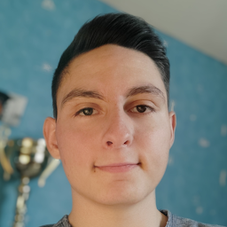

### Apprenti développeur logiciel

> Mon choix pour la filière en architecture logicielle à l’ESGI découle de ma passion pour le développement Back-end et le DevOps. J’y ai trouvé un environnement stimulant pour renforcer mes compétences dans ces domaines et contribuer à la création de systèmes performants et fiables.

## A propos

antonydavid945@gmail.com

[LinkedIn](https://fr.linkedin.com/in/antodavid)

[Github](https://github.com/jayllyz)

## Expériences

**2024 - 2026**

*Développeur & DevOps | Alternance 2 an*  
[Hitachi](https://www.hitachirail.com/) Logiciel de qualification d’équipements électroniques : développement d’une application C++/Qt pour automatiser les tests de résistance. Maintenance d’une API Node.js en production : résolution de bugs, optimisations de performances, correctifs de sécurité et déploiement via Coolify. Refonte majeure d’une solution de gestion de parking en méthode Agile :

- Travail au sein d’une équipe internationale, collaboration avec des testeurs QA
- Développement frontend React et contributions backend Java
- Administration et évolution du cluster Kubernetes (RKE2) : mises à jour, gestion des incidents, supervision de l’infrastructure et déploiement on-premise/cloud
- Suivi DevOps : pipelines CI/CD, gestion de versions, automatisation des tests.

**2023 - 2024**

*Développeur | Alternance 1 an*  
[Thales](https://www.thalesgroup.com/fr) Poursuite et évolution de l’API Node.js développée lors de mon stage : nouvelles fonctionnalités, maintenance et mise en production. Maintenance et évolution d’une application web de supervision de parking (React, Fastify). Dirigé la migration de Mercurial vers Git pour l’enssemble des projets, mettant en place des scripts et des guides pour l’équipe. Évolution d’une solution de test automatisé (TAU) : intégration de nouveaux modules de test, résolution de bugs et maintenance du logiciel. Conçu et développé une application web de gestion des plaques d’immatriculation pour les abonnés d’un parking, utilisant Next.js.

**2023**

*Développeur | Stage 2 mois*  
[Thales](https://www.thalesgroup.com/fr) Conception et développement d’une API Rest en NodeJS avec spécification OpenAPI pour un module de bonifications, incluant la mise en place d’un script en python de synchronisation des tickets des parkings avec le serveur.

- Fastify, Docker, NodeJS, Python

J’ai également joué un rôle dans l’implémentation d’une interface de paramétrage sur la supervision web en react, permettant une gestion des configurations liées au module de bonifications.

- React, Fastify, Blueprint

**2022**

*Développeur web | Stage 1 mois*  
[Premier Octet](https://www.premieroctet.com/) Réalisation d’un site web permettant aux utilisateurs de générer des QR codes pour faire deviner une chaîne de caractères une fois les codes scannés.

- Remix, PostgreSQL, Prisma.

Participation à la préparation du déploiement d’un site web d’e-commerce en Open Source.

- GraphCMS, API GraphQL, Remix

**2021**

*Développeur web | Stage 1 mois*  
[Cap Collectif](https://www.cap-collectif.com/) Utilisation de React/NextJS/GraphQL pour améliorer une plateforme d’analyse de données.

**2015**

*Stage d’observation 5 jours*  
[Jolicode](https://jolicode.com/) Stage d’observation de 5 jours dans une société spécialisée dans le développement Web et mobile avec une initiation des langages web. (HTML/CSS)

## Formations

**2021 - 2024**

*Bachelor européen, Chef de projet logiciel et réseau*  
[ESGI](https://www.esgi.fr/)

**2019 - 2021**

*Cycle préparatoire ingénieur*  
[ESIEA](https://www.esiea.fr/)

**2015 - 2019**

*Baccalauréat S, Sciences de l’ingénieur*  
Option: Informatique et sciences du numérique (ISN)  
[Lycée Langevin-Wallon](https://www.lycee-langevin-wallon.com/)

## Projets

**2023**

*TeamEase* [repo](https://github.com/Jayllyz/TeamEase)  
Réalisation d’un site web, une application Android, un dashbaord statistique, un BOT d’FAQ ainsi que d’une API pour une entreprise de team building dans le cadre du projet annuel de 2ième année.

**2023**

*TaskToDo* [repo](https://github.com/Jayllyz/TaskToDo)  
Logiciel de planification de tâches en C avec l’utilisation de la librairie GTK+3.2 pour l’interface utilisateur réalisée via Glade.

**2022**

*Topcook* [repo](https://github.com/Jayllyz/Topcook)  
Dans le cadre d’un projet de site web dynamique, nous avons décidé de créer un site web communautaire autour des recettes de cuisine.

**2021**

*A star* [repo](https://github.com/Jayllyz/Astar)  
Algorithme de recherche de chemin dans un graphe réalisé dans le cadre d’un projet de deuxième année de cycle préparatoire.

**2019**

*Survive the Tempest* [repo](https://github.com/Jayllyz/SurvivetheTempest)  
Jeu de stratégie réalisé et inventé en duo, programmé en langage Python durant 4 mois en classe de terminale.

## Compétences

C, Typescript, React, NodeJS, Python, PHP, Bash, Java, Rust

Docker, Git, Github Actions, PostgreSQL, Kubernetes, Docker Swarm

## Langues

**Francais**

Natale

**Anglais**

TOEIC 830

> Télécharger [PDF](https://jayllyz.github.io/resume.pdf) | Voir CV en ligne https://jayllyz.github.io/